# Introduction to Tidyverse

Author

Dr. Niloufar Abourashchi and Dr. Thomas Honnor

## Workshop Agenda

### Today’s Tasks

1. Gain familiarity with working with data frames.
2. Learn how to manipulate data frames using the tidyverse package.
3. Understand the basics of working with R scripts and R notebook files.

## The Database **`hsb2`**

The `hsb2` database is taken from a national survey of high school seniors.

More details about the survey can be found here:

- [High School and Beyond - Wikipedia](https://en.wikipedia.org/wiki/High_School_and_Beyond)
- [High School and Beyond - NCES](https://nces.ed.gov/surveys/hsb/)

The data files contains a subset of students randomly sampled from the full database.

## Key details

- Number of **observations**: 200 students
- Number of **variables**: 12

| Variable Name | Type | Details |
| --- | --- | --- |
| female | nominal | (0/1) |
| race | nominal | ethnicity (1=hispanic 2=asian 3=african-american 4=white) |
| ses | ordinal | socioeconomic status (1=low 2=middle 3=high) |
| schtyp | nominal | type of school (1=public 2=private) |
| prog | nominal | type of program (1=general 2=academic) |
| read | scale | standardized reading score |
| write | scale | standardized writing score |
| math | scale | standardized math score |
| science | scale | standardized science score |
| socst | scale | standardized social studies score |
| hon | nominal | passed with honors in English (0/1) |

## Analysis steps:

- Load the data into R
- Check the contents of the loaded data
- Convert the columns into labelled factor variables
- Investigate:
  - reading score vs writing score
  - maths score by race
  - science score by socioeconomic status
  - passed with honors English vs type of school
- Make a new column “english” containing the average of the reading and writing score
- Make a new column “overall” containing the average of the all subject scores
- Compare overall score between male and female students
- Create a new data frame containing only public school students
- Create a new data frame containing only the overall scores and socioeconomic status for public school students.

**Solution**

```r
library(tidyverse)
highschool <- read_csv("hsb2.csv")
# Check the contents of the loaded data
# head(highschool,n = 10)
# dbl means numeric or floating point number data
# glimpse(highschool)
# summary(highschool)
```

### Convert the columns into labelled factor variables

```r
highschool$race <- factor(highschool$race,
                           levels = c(1,2,3,4),
                           labels = c("hispanic",
                                      "asian",
                                      "african-american",
                                      "white") )

highschool$ses <- factor(highschool$ses,
                           levels = c(1,2,3),
                           labels = c("low",
                                      "middle",
                                      "high") )

highschool$gender <- factor(highschool$female,
                         levels = c(0,1),
                         labels = c("male",
                                    "female") )

highschool$schtyp <- factor(highschool$schtyp,
                            levels = c(1,2),
                            labels = c("public",
                                       "private") )
```

### remove column 2 which is female column

```r
highschool <- highschool[ ,-2]
```

### Investigate:

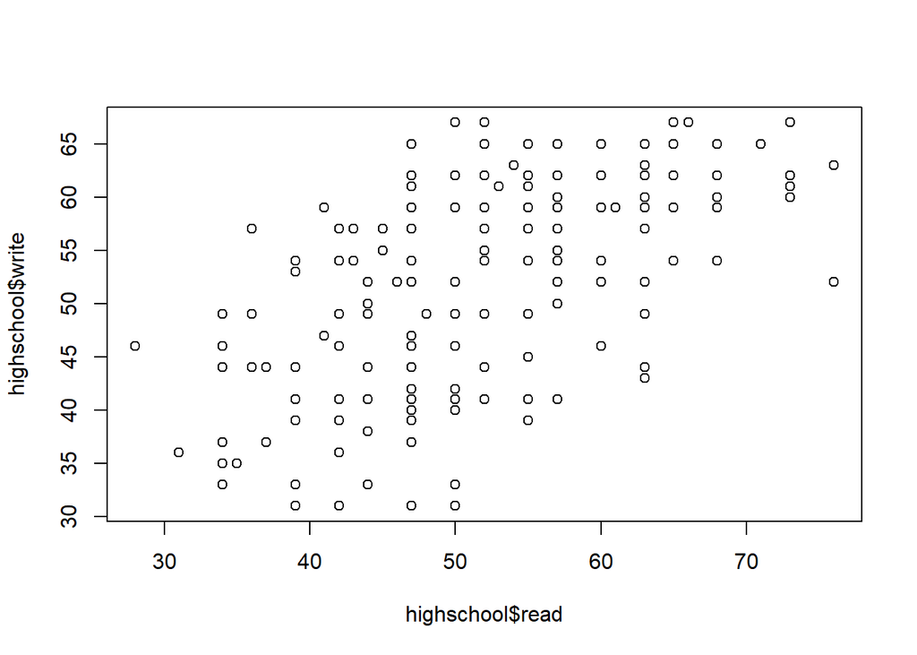

```r
#  - reading score vs writing score
plot(highschool$read,highschool$write)
```

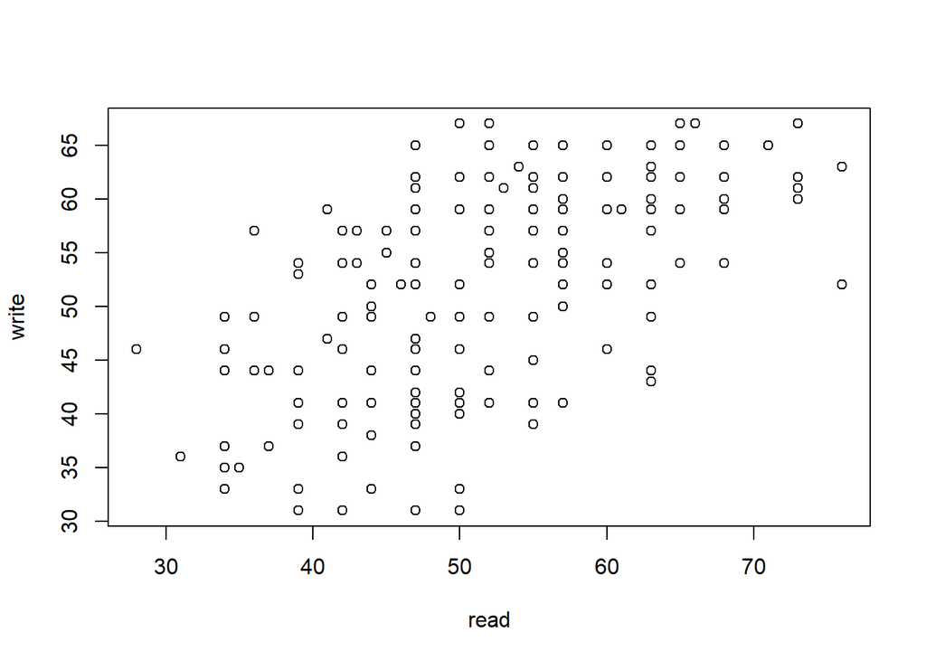

```r
# plot using formula
plot(write~read, data=highschool)
```

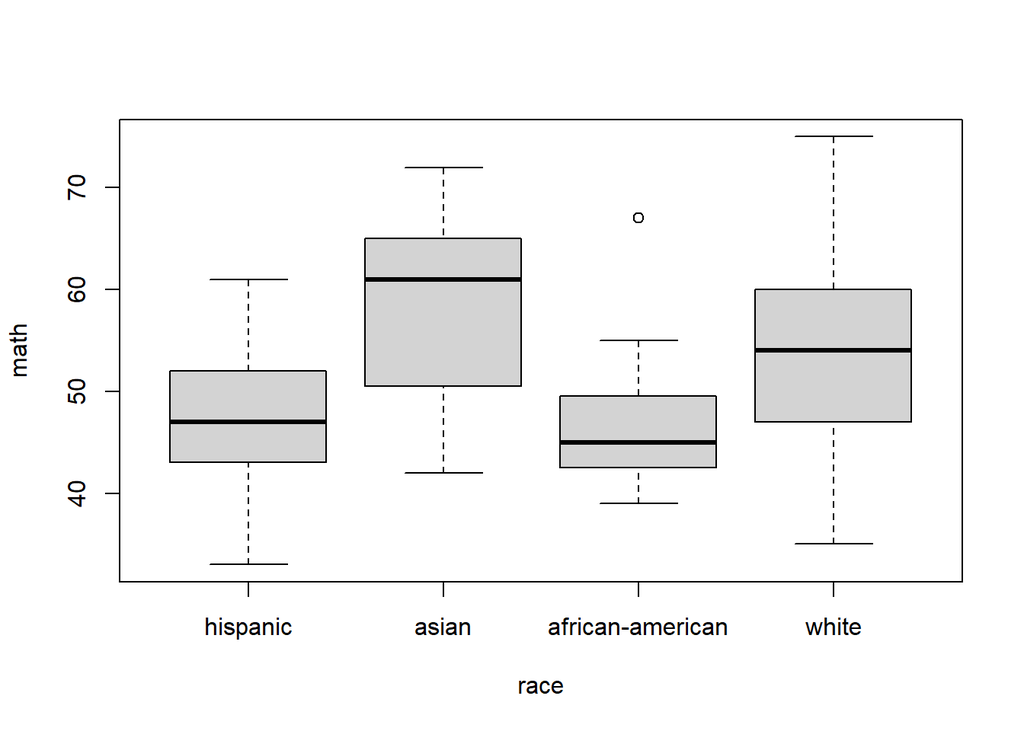

```r
# - maths score by race
plot(math~race, data=highschool)
```

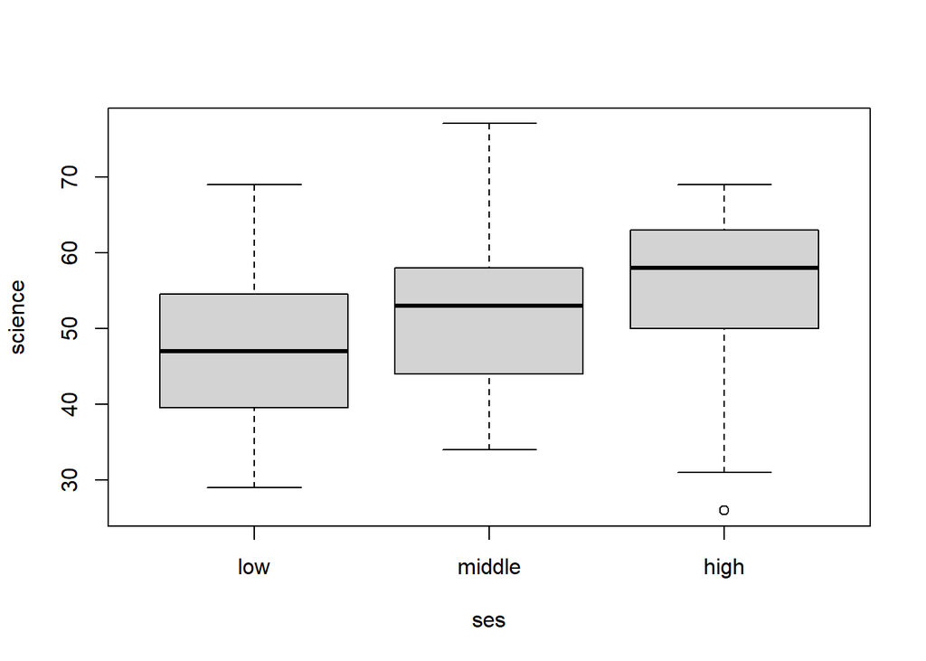

```r
# - science score by socioeconomic status
plot(science~ses,data=highschool)
```

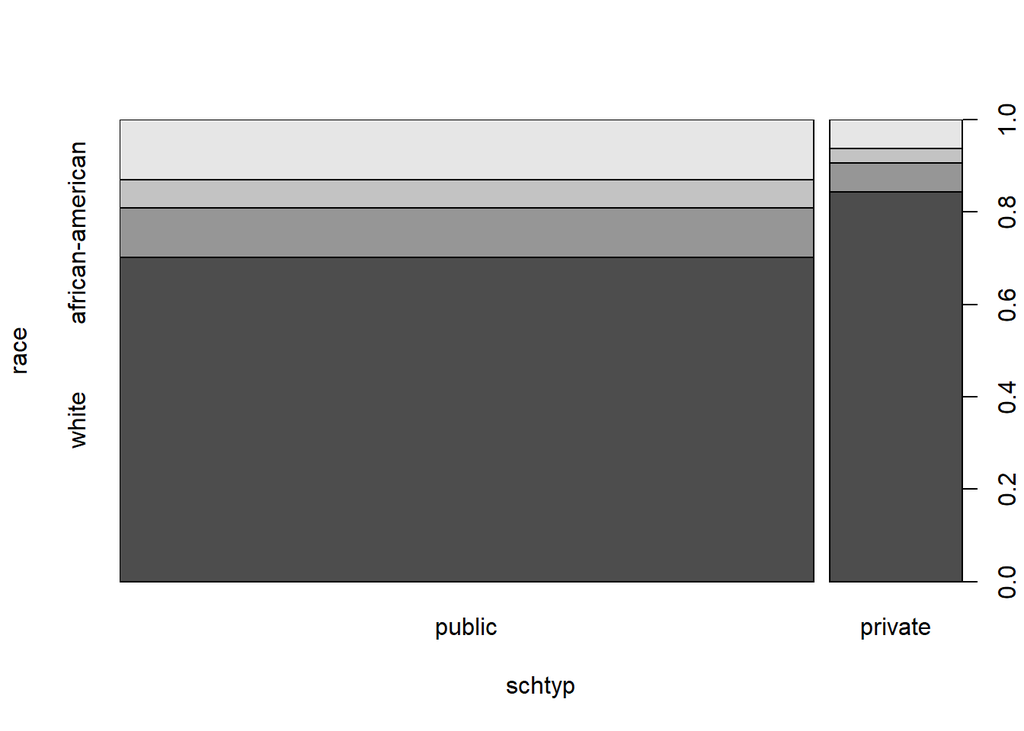

```r
# - race vs type of school
plot(race~schtyp, data=highschool)
```

```r
# frquency table
table(highschool$race,highschool$schtyp)
```

```
                   public private
  hispanic             22       2
  asian                10       1
  african-american     18       2
  white               118      27
```

### Make a new column “english” containing the average of the reading and writing score Make a new column “overall” containing the average of the all subject scores

```r
highschool$english <- (highschool$write + highschool$read)/2
```

### Compare overall score between male and female students

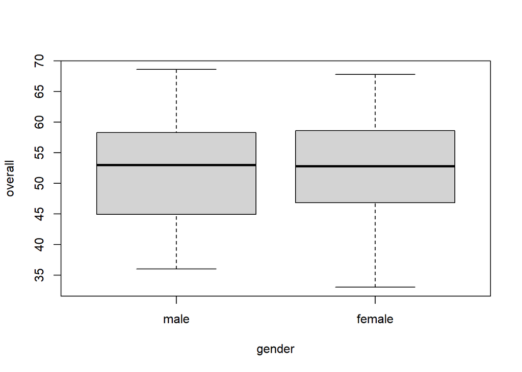

```r
highschool$overall <- (highschool$write +
                         highschool$read +
                         highschool$math +
                         highschool$science +
                         highschool$socst )/5

plot(overall~gender,data=highschool)
```

### Create a new data frame containing only public school students

```r
highschool_public <- subset(highschool, schtyp=="public")
highschool_public2 <- highschool[ which(highschool$schtyp=="public") , ]
```

### Create a new data frame containing only the overall scores and socioeconomic status for public school students.

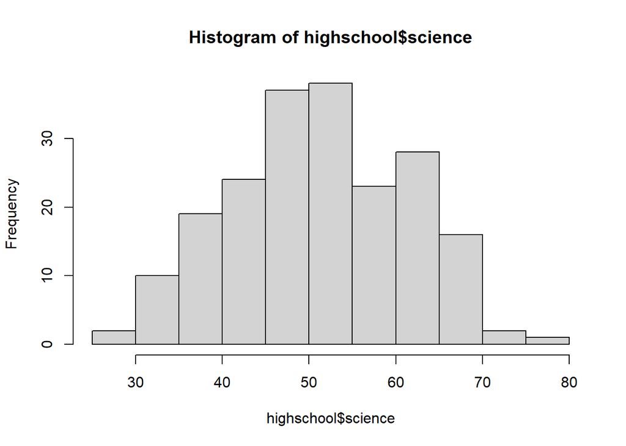

```r
highschool_summary <- highschool[ , c('overall','ses')]
hist(highschool$science)
```

```r
mean(highschool$science)
```

```
[1] 51.865
```

```r
highschool3 <- subset(highschool, science>=50 & science<60)
```

**Exercise: Analysis of the children bodysize dataset**

The file `children_bodysize.csv` contains body size measurements of children. Use the R commands we have covered to open and explore the dataset.

- **weight**: mass in kg
- **stature**: height in mm
- **head**: head circumference in mm
- **shoulder**: shoulder breadth in mm
- **hand_l**: hand length
- **hand_w**: hand width
- **waist**: waist circumference
- **foot_l**: foot length
- **foot_w**: foot width
- **gender**: gender
- **age**: age (months)

Work in an R markdown file so that you can reproduce and share your work easily.

1. Import the Tidyverse libraries
2. Load the data into a data frame
3. Check data types for each column
4. Plot showing heights vs age

### Answer the questions

1. How many entries are in the dataset?
2. What are the youngest and oldest ages of individuals in the dataset?
3. What is the tallest individual in the dataset, are they male or female?
4. How many boys are in the dataset?
5. How many girls over the age of 12?
6. What is the mean height of a 5 year old boy and 5 year old girl?
7. What is the mean height of a 15 year old boy and 15 year old girl?
8. Use a histogram to show the distribution of children’s ages
9. What does the distribution of the heights of 9 year old males look like?

### Challenges

- Create a column height_cm containing the height in cm (1cm = 10mm)
- Create a column containing the age in years
- Plot showing the average height of children by age

**Solution**

```r
library("tidyverse")
```

Now we can load in the datafile and tidy it up:

```r
bodysize <- read_csv("children_bodysize.csv")
bodysize$height <- bodysize$stature/10
bodysize$age <- bodysize$age/12
bodysize$year_old <- floor(bodysize$age)
bodysize$gender <- factor(bodysize$gender)
bodysize
```

```
# A tibble: 3,741 × 14
   weight stature  head shoulder hand_l hand_w chest waist foot_l foot_w gender
    <dbl>   <dbl> <dbl>    <dbl>  <dbl>  <dbl> <dbl> <dbl>  <dbl>  <dbl> <fct>
 1   15.8    1033   498      282    120     55   526   475    163     67 F
 2   17.9    1039   506      273    121     56   564   498    163     67 M
 3   23.5    1112   512      309    121     59   601   520    171     65 F
 4   16.8     997   489      253    116     51   532   491    163     61 F
 5   15.3     997   473      273    114     51   501   465    167     64 F
 6   18.3     987   513      279    114     55   558   503    164     66 M
 7   13.7     941   507      249    101     52   503   459    150     61 M
 8   13.8     933   490      251    109     50   502   461    150     61 F
 9   19.8    1164   529      296    125     59   553   507    175     69 F
10   19.2    1100   524      284    123     56   563   535    172     65 F
# ℹ 3,731 more rows
# ℹ 3 more variables: age <dbl>, height <dbl>, year_old <dbl>
```

Now lets compare the average height of 15 year old boys vs girls.

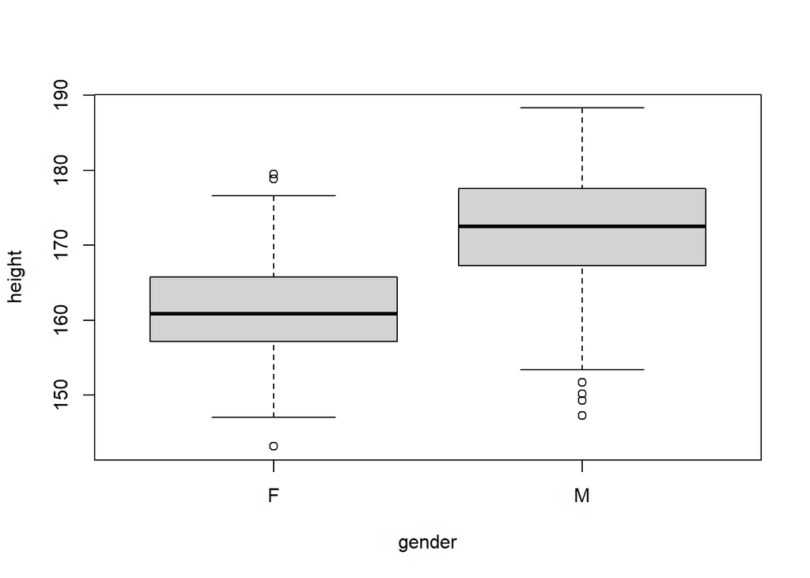

```r
plot(height ~ gender,
     data = subset(bodysize, year_old==15 )
)
```

Plot height against age.

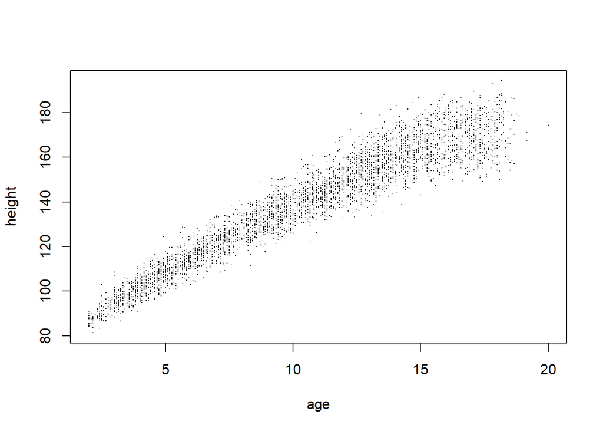

```r
plot(height~age, data=bodysize, pch='.')
```

#### Using Tidyverse functions

If we need to convert a data frame to a tidyverse tibble we can use the tibble function:

```r
# if we have a data.frame which is not already a tibble
# we can think of data frames and tibbles as being the same
# one difference is that tibbles don't have row names/labels
bodysize <- tibble(bodysize)
```

#### The `select` command

Select allows us to select columns from a data frame.

```r
bodysize_modified <- select(bodysize, height, gender, age, year_old)
bodysize_modified
```

```
# A tibble: 3,741 × 4
   height gender   age year_old
    <dbl> <fct>  <dbl>    <dbl>
 1  103.  F       4.17        4
 2  104.  M       4.25        4
 3  111.  F       4.42        4
 4   99.7 F       3.83        3
 5   99.7 F       3.42        3
 6   98.7 M       3.67        3
 7   94.1 M       3.33        3
 8   93.3 F       3.58        3
 9  116.  F       5.5         5
10  110   F       5.17        5
# ℹ 3,731 more rows
```

#### The `filter` command

Filter allows us to select rows from a data frame.

```r
bodysize_girls_5_to_10 <- filter(bodysize, gender=='F' & age>=5 & age<10)
bodysize_girls_5_to_10 <- filter(bodysize, gender=='F', age>=5, age<10)

summary(bodysize_girls_5_to_10)
```

```
     weight         stature          head          shoulder         hand_l
 Min.   :15.20   Min.   : 992   Min.   :466.0   Min.   :235.0   Min.   :104.0
 1st Qu.:21.00   1st Qu.:1159   1st Qu.:502.0   1st Qu.:280.0   1st Qu.:126.0
 Median :24.50   Median :1239   Median :514.0   Median :296.0   Median :134.0
 Mean   :25.80   Mean   :1239   Mean   :514.2   Mean   :300.4   Mean   :135.2
 3rd Qu.:29.48   3rd Qu.:1320   3rd Qu.:527.0   3rd Qu.:318.0   3rd Qu.:143.0
 Max.   :61.20   Max.   :1504   Max.   :572.0   Max.   :409.0   Max.   :181.0
     hand_w          chest         waist           foot_l          foot_w
 Min.   :48.00   Min.   :489   Min.   :451.0   Min.   :148.0   Min.   :58.00
 1st Qu.:58.00   1st Qu.:570   1st Qu.:515.2   1st Qu.:180.0   1st Qu.:70.00
 Median :61.00   Median :603   Median :546.5   Median :193.0   Median :74.00
 Mean   :61.59   Mean   :613   Mean   :561.1   Mean   :193.1   Mean   :74.53
 3rd Qu.:65.00   3rd Qu.:647   3rd Qu.:588.8   3rd Qu.:205.0   3rd Qu.:79.00
 Max.   :78.00   Max.   :925   Max.   :897.0   Max.   :254.0   Max.   :95.00
 gender       age            height         year_old
 F:566   Min.   :5.000   Min.   : 99.2   Min.   :5.000
 M:  0   1st Qu.:6.250   1st Qu.:115.9   1st Qu.:6.000
         Median :7.500   Median :123.9   Median :7.000
         Mean   :7.568   Mean   :123.9   Mean   :7.097
         3rd Qu.:8.917   3rd Qu.:132.0   3rd Qu.:8.000
         Max.   :9.917   Max.   :150.4   Max.   :9.000
```

#### The `mutate` command

Mutate allows us to take columns and use them to create new columns

```r
bodysize_modified <- mutate(bodysize, height_m = height/100)
bodysize_modified
```

```
# A tibble: 3,741 × 15
   weight stature  head shoulder hand_l hand_w chest waist foot_l foot_w gender
    <dbl>   <dbl> <dbl>    <dbl>  <dbl>  <dbl> <dbl> <dbl>  <dbl>  <dbl> <fct>
 1   15.8    1033   498      282    120     55   526   475    163     67 F
 2   17.9    1039   506      273    121     56   564   498    163     67 M
 3   23.5    1112   512      309    121     59   601   520    171     65 F
 4   16.8     997   489      253    116     51   532   491    163     61 F
 5   15.3     997   473      273    114     51   501   465    167     64 F
 6   18.3     987   513      279    114     55   558   503    164     66 M
 7   13.7     941   507      249    101     52   503   459    150     61 M
 8   13.8     933   490      251    109     50   502   461    150     61 F
 9   19.8    1164   529      296    125     59   553   507    175     69 F
10   19.2    1100   524      284    123     56   563   535    172     65 F
# ℹ 3,731 more rows
# ℹ 4 more variables: age <dbl>, height <dbl>, year_old <dbl>, height_m <dbl>
```

```r
bodysize <- read_csv("children_bodysize.csv")
bodysize_mod <- mutate(bodysize,
                       age = age/12,
                       gender = factor(gender),
                       year_old = floor(age),
                       height = stature/10)
bodysize_mod
```

```
# A tibble: 3,741 × 14
   weight stature  head shoulder hand_l hand_w chest waist foot_l foot_w gender
    <dbl>   <dbl> <dbl>    <dbl>  <dbl>  <dbl> <dbl> <dbl>  <dbl>  <dbl> <fct>
 1   15.8    1033   498      282    120     55   526   475    163     67 F
 2   17.9    1039   506      273    121     56   564   498    163     67 M
 3   23.5    1112   512      309    121     59   601   520    171     65 F
 4   16.8     997   489      253    116     51   532   491    163     61 F
 5   15.3     997   473      273    114     51   501   465    167     64 F
 6   18.3     987   513      279    114     55   558   503    164     66 M
 7   13.7     941   507      249    101     52   503   459    150     61 M
 8   13.8     933   490      251    109     50   502   461    150     61 F
 9   19.8    1164   529      296    125     59   553   507    175     69 F
10   19.2    1100   524      284    123     56   563   535    172     65 F
# ℹ 3,731 more rows
# ℹ 3 more variables: age <dbl>, year_old <dbl>, height <dbl>
```

#### The `arrange` command

Arrange allows us to sort data

```r
sorted_by_height <- arrange(bodysize_mod, height)
sorted_by_height
```

```
# A tibble: 3,741 × 14
   weight stature  head shoulder hand_l hand_w chest waist foot_l foot_w gender
    <dbl>   <dbl> <dbl>    <dbl>  <dbl>  <dbl> <dbl> <dbl>  <dbl>  <dbl> <fct>
 1   10.4     813   497      213     87     42   464   422    116     56 M
 2   10.9     833   458      213     93     46   450   428    128     56 M
 3   10.7     838   472      234     91     48   444   441    119     52 F
 4   12.6     842   473      232    100     50   478   469    131     62 F
 5   11.9     842   497      237     91     46   498   485    132     60 F
 6   11.5     846   467      240     97     45   467   457    123     53 F
 7   11.6     852   481      207     94     45   459   461    134     53 F
 8   12.4     854   477      232     99     46   491   500    131     53 F
 9   12.1     855   479      224     93     45   473   457    129     58 M
10   14.1     858   490      261    102     54   484   476    142     63 F
# ℹ 3,731 more rows
# ℹ 3 more variables: age <dbl>, year_old <dbl>, height <dbl>
```

```r
sorted_by_height2 <- arrange(bodysize_mod, desc(height) )
sorted_by_height2
```

```
# A tibble: 3,741 × 14
   weight stature  head shoulder hand_l hand_w chest waist foot_l foot_w gender
    <dbl>   <dbl> <dbl>    <dbl>  <dbl>  <dbl> <dbl> <dbl>  <dbl>  <dbl> <fct>
 1  114.     1944   594      509    192     96  1075  1053    301    128 M
 2   84.8    1931   580      450    212    101   941   815    300    111 M
 3   78.7    1896   591      444    217     95   939   752    300    104 M
 4   85.4    1884   571      492    208     99  1005   804    298    109 M
 5   96.7    1883   583      467    193     88  1079   965    272    101 M
 6   72.6    1880   558      441    194     89   916   762    273    104 M
 7   74.4    1878   566      459    199     88   906   773    275    104 M
 8   72.8    1876   552      461    194     89   907   734    282    112 M
 9   94.3    1868   577      454    198     91  1006   965    281     99 M
10   83.4    1868   573      502    192     89  1038   784    269    107 M
# ℹ 3,731 more rows
# ℹ 3 more variables: age <dbl>, year_old <dbl>, height <dbl>
```

#### The `group_by` and `summarise` command

We can summarise information based on groups using the above commands.

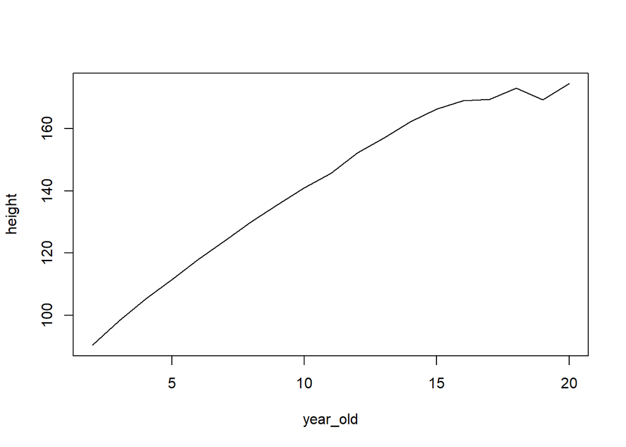

```r
bodysize_mod <- group_by(bodysize_mod, year_old)
height_by_age <- summarise(bodysize_mod, height = mean(height) )
plot(height~year_old, data=height_by_age, type="line")
```

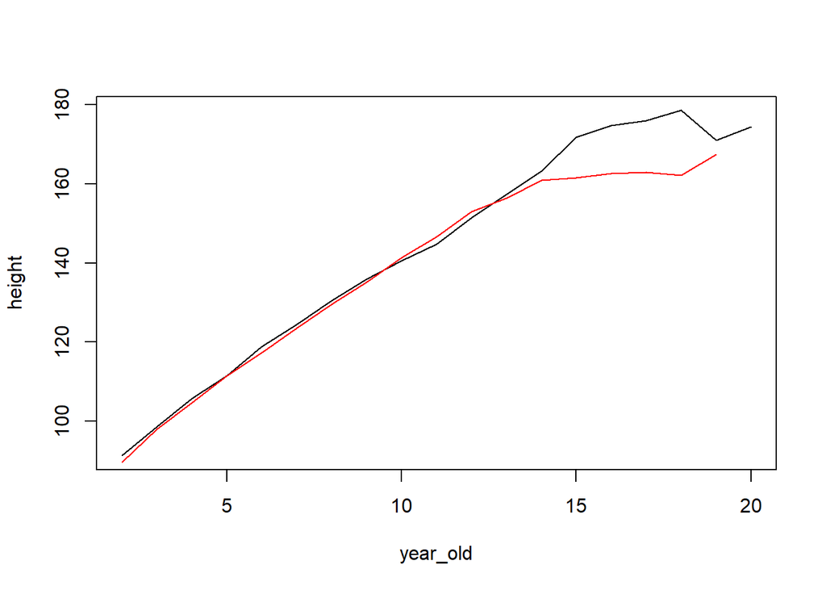

```r
bodysize_mod <- group_by(bodysize_mod, year_old, gender)
height_by_age <- summarise(bodysize_mod, height = mean(height) )
plot(height~year_old, type="line", data=filter(height_by_age, gender=='M'))
lines(height~year_old, col="red", data=filter(height_by_age, gender=='F'))
```